# Community ecology - Computer lab I - AB332

Anders K. Krabberød (UiO) and Ramiro Logares (ICM)

October 2023

Make sure you have installed all packages!

# Starting community ecology analyses

Read the data from the github page: https://github.com/krabberod/UNIS_AB332_2023

```r
otu.tab <- read_tsv("https://raw.githubusercontent.com/krabberod/UNIS_AB332_2023/main/computer_lab/data/AB332_otutab_reduc3.txt")
```

First, get to know the data: - *How many samples and how many OTUs are in the dataset?* - *What do the numbers in the sample names mean?*

```r
head(otu.tab)
```

| OTUNumber | Isa_111214 | Isa_120117 | Isa_120128 | Isa_120209 | Isa_120216 | Isa_120223 | Isa_120301 | Isa_120308 | Isa_120320 | Isa_120321 | Isa_120322 | Isa_120323 | Isa_120329 | Isa_120403 | Isa_120411 | Isa_120416 | Isa_120419 | Isa_120423 | Isa_120426 | Isa_120430 | Isa_120503 | Isa_120507 | Isa_120508 | Isa_120509 | Isa_120510 | Isa_120516 | Isa_120524 | Isa_120621 | Isa_120706 | … |
| --- | --- | --- | --- | --- | --- | --- | --- | --- | --- | --- | --- | --- | --- | --- | --- | --- | --- | --- | --- | --- | --- | --- | --- | --- | --- | --- | --- | --- | --- | --- |
| OTU1 | 436 | 348 | 236 | 139 | 260 | 446 | 149 | 321 | 204 | 442 | 245 | 215 | 175 | 170 | 333 | 1327 | 1362 | 2597 | 4805 | 8139 | 5255 | 8745 | 9710 | 4587 | 11100 | 16900 | 19900 | 1152 | 1785 | … |
| OTU10 | 2308 | 2537 | 1599 | 1956 | 328 | 668 | 551 | 1462 | 896 | 646 | 616 | 643 | 379 | 475 | 661 | 399 | 105 | 81 | 20 | 9 | 6 | 0 | 5 | 0 | 0 | 0 | 0 | 96 | 0 | … |
| OTU100 | 83 | 36 | 21 | 30 | 1 | 21 | 23 | 99 | 75 | 61 | 40 | 47 | 44 | 46 | 74 | 201 | 21 | 4 | 0 | 1 | 0 | 0 | 0 | 0 | 0 | 1 | 0 | 3 | 2 | … |
| OTU1000 | 0 | 0 | 0 | 0 | 0 | 0 | 1 | 11 | 1 | 4 | 2 | 3 | 8 | 4 | 4 | 3 | 0 | 0 | 0 | 0 | 2 | 0 | 0 | 0 | 0 | 0 | 0 | 3 | 3 | … |
| OTU1001 | 1 | 0 | 0 | 0 | 0 | 2 | 1 | 0 | 0 | 0 | 0 | 0 | 0 | 0 | 0 | 0 | 0 | 0 | 0 | 0 | 0 | 0 | 0 | 0 | 0 | 0 | 0 | 0 | 1 | … |
| OTU1002 | 0 | 2 | 0 | 1 | 0 | 0 | 2 | 7 | 2 | 2 | 1 | 3 | 2 | 2 | 7 | 0 | 0 | 0 | 0 | 0 | 0 | 0 | 0 | 0 | 0 | 0 | 0 | 0 | 0 | … |

```r
dim(otu.tab)
```

```
[1] 3697   83
```

You can look at a given selection of the table by specifying a range of rows and columns:

```r
otu.tab[5:15, 1:5] # The first 10 rows, and the first 5 columns
```

| OTUNumber | Isa_111214 | Isa_120117 | Isa_120128 | Isa_120209 |
| --- | --- | --- | --- | --- |
| OTU1001 | 1 | 0 | 0 | 0 |
| OTU1002 | 0 | 2 | 0 | 1 |
| OTU1003 | 3 | 0 | 0 | 0 |
| OTU1004 | 9 | 2 | 5 | 7 |
| OTU1005 | 1 | 0 | 2 | 0 |
| OTU1006 | 0 | 2 | 0 | 4 |
| OTU1007 | 0 | 0 | 0 | 0 |
| OTU1008 | 0 | 0 | 0 | 0 |
| OTU1009 | 0 | 0 | 0 | 1 |
| OTU101 | 3 | 0 | 0 | 0 |

[output cut: 1 more lines]

You can also see the entire table with the `View()` function:

```
View(otu.tab)
```

- *See if you can choose a different subset. For instance samples 6-12 and OTUs 20-26:*

Assign OTU-numbers as rownames

```r
otu.tab <- column_to_rownames(otu.tab, var = "OTUNumber")
```

Let’s check the names

```r
head(rownames(otu.tab))
```

```
[1] "OTU1"    "OTU10"   "OTU100"  "OTU1000" "OTU1001" "OTU1002"
```

```r
dim(otu.tab)
```

```
[1] 3697   82
```

```r
colnames(otu.tab)
```

```
 [1] "Isa_111214" "Isa_120117" "Isa_120128" "Isa_120209" "Isa_120216" "Isa_120223" "Isa_120301" "Isa_120308" "Isa_120320" "Isa_120321" "Isa_120322" "Isa_120323"
[13] "Isa_120329" "Isa_120403" "Isa_120411" "Isa_120416" "Isa_120419" "Isa_120423" "Isa_120426" "Isa_120430" "Isa_120503" "Isa_120507" "Isa_120508" "Isa_120509"
[25] "Isa_120510" "Isa_120516" "Isa_120524" "Isa_120621" "Isa_120706" "Isa_120806" "Isa_120823" "Isa_120906" "Isa_120918" "Isa_121031" "Isa_121115" "Isa_121129"
[37] "Isa_121206" "Isa_121213" "Isa_130110" "Isa_130123" "Isa_130130" "Isa_130219" "Isa_130301" "Isa_130307" "Isa_130315" "Isa_130320" "Isa_130405" "Isa_130411"
[49] "Isa_130419" "Isa_130424" "Isa_130502" "Isa_130510" "Isa_130515" "Isa_130524" "Isa_130530" "Isa_130605" "Isa_130612" "Isa_130619" "Isa_130710" "Isa_130724"
[61] "Isa_130807" "Isa_130823" "Isa_130908" "Isa_131009" "Isa_140121" "Isa_140221" "Isa_140226" "Isa_140401" "Isa_140410" "Isa_140423" "Isa_140429" "Isa_140502"
[73] "Isa_140507" "Isa_140514" "Isa_140522" "Isa_140528" "Isa_140604" "Isa_140611" "Isa_140618" "Isa_140904" "Isa_141009" "Isa_141024"
```

For simplicity, I have included only 25 samples in the rest of the tutorial. As an exercise, *you could redo the analysis with the full dataset*. I.e. remove the part of the code that selects particular samples in the following chunk.  
This way your numbers will differ from the pdf, and you can also see the effect of a different dataset.s

```r
otu.tab.red <- otu.tab[, 6:30]
```

The data needs to be transposed since this is how Vegan likes it (i.e. Vegan prefers OTUs as columns, and Samples as rows).

```r
otu.tab.trans <- t(otu.tab.red)
otu.tab.trans[1:5, 1:5]
```

```
           OTU1 OTU10 OTU100 OTU1000 OTU1001
Isa_120223  446   668     21       0       2
Isa_120301  149   551     23       1       1
Isa_120308  321  1462     99      11       0
Isa_120320  204   896     75       1       0
Isa_120321  442   646     61       4       0
```

You can get the total number of reads for each sample using rowSums(). and the total reads per OTU with colSums().  
- *Do you understand what these two functions do just by looking at their names?*

```r
rowSums(otu.tab.trans)
```

```
Isa_120223 Isa_120301 Isa_120308 Isa_120320 Isa_120321 Isa_120322 Isa_120323 Isa_120329 Isa_120403 Isa_120411 Isa_120416 Isa_120419 Isa_120423 Isa_120426 Isa_120430
     13682      15783      32833      19361      17110      13658      16251      17002      13551      25606      29877      16194      17161      22305      19942
Isa_120503 Isa_120507 Isa_120508 Isa_120509 Isa_120510 Isa_120516 Isa_120524 Isa_120621 Isa_120706 Isa_120806
     25237      27389      19969      34666      17682      25256      40267      24636      23156      20390
```

```r
head(colSums(otu.tab.trans)) # Too many to show them all.
```

```
   OTU1   OTU10  OTU100 OTU1000 OTU1001 OTU1002
 100420    7814     786      54       4      28
```

- *Can you figure out a way to view only the last part of the the list of total reads per OTU? Hint: look up the help file for the head() function*:

```r
?head
```

Since I have selected only a few of the samples is possible that some of the OTU’s are left with a total abundance of zero. In R it is possible to have functions within functions so the following will print the number of columns in the data set that has a sum equal to 0:

```r
length(which(colSums(otu.tab.trans) == 0))
```

```
[1] 1163
```

This code is nested so that R reads evaluates the innermost function first (i.e `colSums()`), then applies the next function to that result (i.e. `which (...) ==0`), then finally the outermost function `lenght()`. In “normal” language the nested function asks: what is the length of the list of column-sums which are exactly zero.

We can use the same idea of a function within a function to exclude the OTUs with a total number of 0. In the next chunk we use the square brackets to make a selection in the dataframe (as before), and add a ‘-’ to get the opposite of what is evaluated by the function.

```r
otu.tab.trans <- otu.tab.trans[, -(which(colSums(otu.tab.trans) == 0))]
```

Now how many are 0?

```r
length(which(colSums(otu.tab.trans) == 0))
```

```
[1] 0
```

How many have more than 0 reads?

```r
length(which(colSums(otu.tab.trans) > 0))
```

```
[1] 2534
```

Can you find how many OTU’s that have more than 10 reads (in total)?

## Common metrics and methods

The following calculations make use of functions in the vegan package written by Jari Oksanen.  
*Vegan is an R package for community ecologists. It contains the most popular methods of multivariate analysis needed in analyzing ecological communities, and tools for diversity analysis, and other potentially useful functions*. If you want to learn more about the vegan package you can check out the vignette (a form for introduction) by running: `browseVignettes("vegan")`

### Rarefaction

Let’s calculate the number of reads per sample as rarefaction curves:

```r
rowSums(otu.tab.trans)
```

```
Isa_120223 Isa_120301 Isa_120308 Isa_120320 Isa_120321 Isa_120322 Isa_120323 Isa_120329 Isa_120403 Isa_120411 Isa_120416 Isa_120419 Isa_120423 Isa_120426 Isa_120430
     13682      15783      32833      19361      17110      13658      16251      17002      13551      25606      29877      16194      17161      22305      19942
Isa_120503 Isa_120507 Isa_120508 Isa_120509 Isa_120510 Isa_120516 Isa_120524 Isa_120621 Isa_120706 Isa_120806
     25237      27389      19969      34666      17682      25256      40267      24636      23156      20390
```

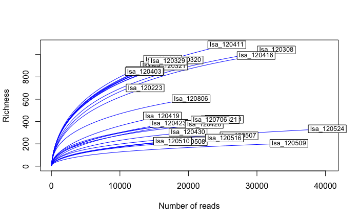

```r
rarecurve(otu.tab.trans, step = 100, xlab = "Number of reads", ylab = "Richness", col = "blue")
```

How do you interpret these curves? Which samples have the lowest number of total reads? Which are the highest?

### Accumulation curves

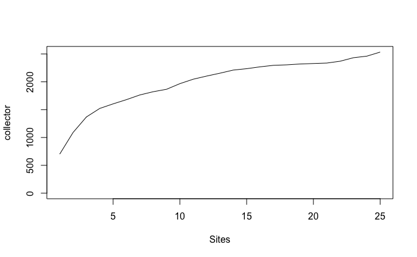

```r
accum.curve <- specaccum(otu.tab.trans, method = "collector")
plot(accum.curve)
```

What does this curve represent? How do you interpret it?

### Richness estimations

Now lets do some ecology:

“The abundance-based estimates in estimateR use counts (numbers of individuals) of species in a single site. If called for a matrix or data frame, the function will give separate estimates for each site. The two variants of extrapolated richness in estimateR are bias-corrected Chao and Abundance-based Coverage Estimator (ACE) (O’Hara 2005, Chiu et al. 2014).”

```r
richness <- estimateR(otu.tab.trans, smallsample = TRUE)
richness
```

```
         Isa_120223 Isa_120301 Isa_120308 Isa_120320 Isa_120321 Isa_120322 Isa_120323 Isa_120329 Isa_120403 Isa_120411 Isa_120416 Isa_120419 Isa_120423 Isa_120426
S.obs     701.00000  902.00000 1042.00000  952.00000  897.00000  858.00000  959.00000  942.00000  848.00000 1088.00000  992.00000  450.00000  384.00000  374.00000
S.chao1  1100.22581 1260.69343 1355.30612 1316.81633 1200.76642 1337.40517 1377.95000 1397.55469 1155.65000 1517.36486 1287.23077  731.44286  693.25532  511.60000
se.chao1   66.62128   54.17742   47.66939   53.77784   47.47591   72.14089   60.96351   67.07142   47.65508   61.13897   44.73270   54.74508   67.46164   32.24236
S.ACE    1036.24030 1249.23447 1337.63473 1341.50902 1197.73116 1278.33686 1365.23150 1356.87666 1181.99016 1480.20490 1295.47022  759.36594  652.06713  539.26272
se.ACE     17.06514   18.59112   18.50405   19.72472   17.80976   19.74198   19.72705   19.88369   18.05970   20.02279   18.55676   16.47752   14.78726   12.98133
         Isa_120430 Isa_120503 Isa_120507 Isa_120508 Isa_120509 Isa_120510 Isa_120516 Isa_120524 Isa_120621 Isa_120706 Isa_120806
S.obs     304.00000  420.00000  272.00000 219.000000 205.000000  224.00000  252.00000  335.00000  417.00000  414.00000  605.00000
S.chao1   438.63830  654.23077  447.77778 324.636364 363.052632  371.17143  369.00000  528.75000  618.88235  582.52174  873.07692
se.chao1   34.05155   48.23404   45.97426  31.165443  51.971891   40.07574   33.24605   48.16268   46.10172   36.35228   50.85980
S.ACE     435.54374  684.48661  432.26064 329.851638 304.844016  395.87277  364.99135  514.52628  590.13947  615.28756  851.28562
se.ACE     10.86998   15.37044   11.73649   9.569067   9.305907   12.00009   10.37553   12.39624   13.01145   13.57143   15.83698
```

If you only want to look at one sample

```r
richness <- estimateR(otu.tab.trans[1,], smallsample = TRUE)
richness
```

```
     S.obs    S.chao1   se.chao1      S.ACE     se.ACE
 701.00000 1100.22581   66.62128 1036.24030   17.06514
```

Above we have the estimators Chao and ACE as well as the species number. What do the numbers mean?

### Evenness

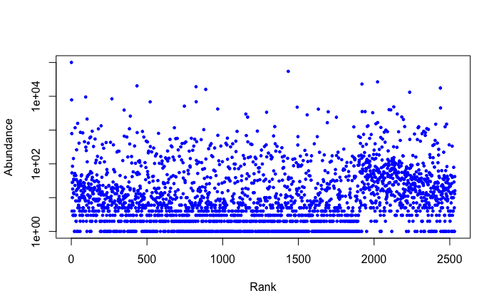

```r
plot(colSums(otu.tab.trans), log = "y", xlab = "Rank", ylab = "Abundance", pch = 19, cex = 0.5, col = "blue")
```

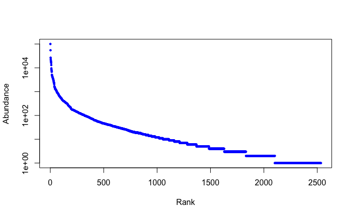

```r
plot(sort(colSums(otu.tab.trans), decreasing = TRUE), log = "y", xlab = "Rank", ylab = "Abundance", pch = 19, cex = 0.5, col = "blue")
```

### Fitting rank-abundance distribution models to the data

Function radfit() constructs rank – abundance or dominance / diversity or Whittaker plots and fit brokenstick, preemption, log-Normal, Zipf and Zipf-Mandelbrot models of species abundance.

```r
mod <- radfit(otu.tab.trans)
```

```
Error in glm.fit(x = structure(c(1, 1, 1, 1, 1, 1, 1, 1, 1, 1, 1, 1, 1,  :
  NA/NaN/Inf in 'x'
Warning: glm.fit: algorithm did not convergeWarning: glm.fit: algorithm did not converge
```

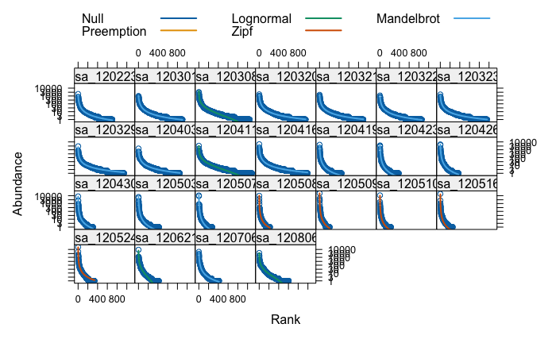

```r
plot(mod)
```

And for all species

```r
mod.all <- radfit(colSums(otu.tab.trans))
```

```
Error in glm.fit(x = structure(c(1, 1, 1, 1, 1, 1, 1, 1, 1, 1, 1, 1, 1,  :
  NA/NaN/Inf in 'x'
```

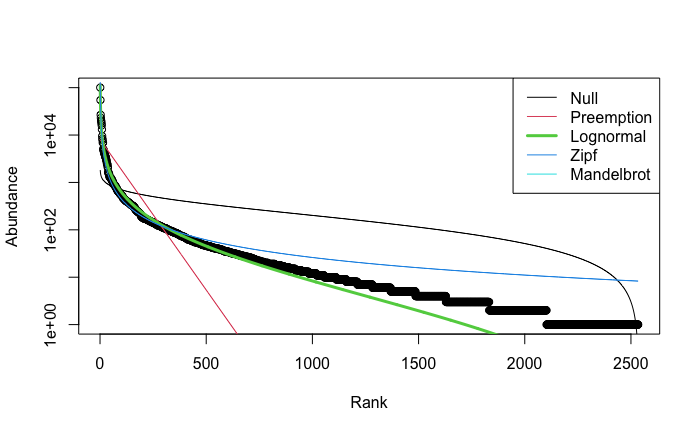

```r
plot(mod.all)
```

### Fitting data to the Preston model

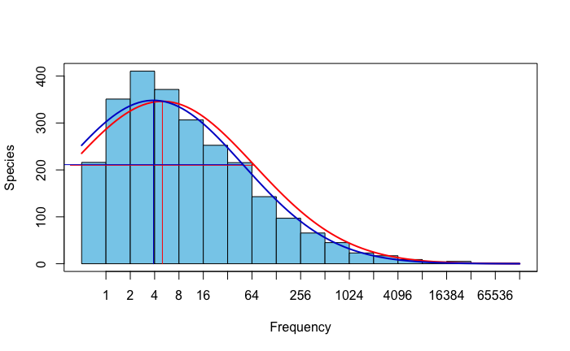

```r
preston <- prestonfit(colSums(otu.tab.trans))
preston.dist <- prestondistr(colSums(otu.tab.trans))
plot(preston)
lines(preston.dist, line.col = "blue3")
```

### Extrapolated richness

```r
veiledspec(preston)
```

```
Extrapolated     Observed       Veiled
   3278.6837    2534.0000     744.6837
```

```r
veiledspec(preston.dist)
```

```
Extrapolated     Observed       Veiled
   3211.9212    2534.0000     677.9212
```

### Shannon H index (considers richness and evenness)

A diversity index taking into account the number of individuals as well as the number of taxa. Varies from 0 for communities with only a single taxon to high values for communities with many taxa, each with few individuals

```r
H <- diversity(otu.tab.trans, index = "shannon")
H
```

```
Isa_120223 Isa_120301 Isa_120308 Isa_120320 Isa_120321 Isa_120322 Isa_120323 Isa_120329 Isa_120403 Isa_120411 Isa_120416 Isa_120419 Isa_120423 Isa_120426 Isa_120430
  4.407409   4.902868   4.679546   4.859799   4.844499   4.826550   4.900137   4.725430   4.914670   4.872817   4.400562   3.203907   2.970289   3.211268   2.520753
Isa_120503 Isa_120507 Isa_120508 Isa_120509 Isa_120510 Isa_120516 Isa_120524 Isa_120621 Isa_120706 Isa_120806
  2.781324   2.086866   2.028217   1.709035   1.784380   1.662585   2.295421   3.245357   3.311757   4.199123
```

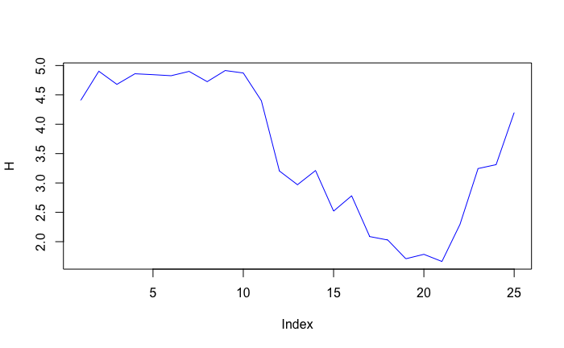

```r
plot(H, type = "l", col = "blue")
```

### Pielou’s index of evenness (range 0-1, 1 = maximum evenness)

`J=H/Hmax`  
`J=Shannon (H) / log(S=species richness)` A calculated value of Pielou’s evenness ranges from 0 (no evenness) to 1 (complete evenness).

```r
J <- H / log(rowSums(otu.tab.trans > 0))
```

### Inverse Simpson’s D index (richness+evenness. Larger values, larger diversity)

The value of Simpson’s D ranges from 0 to 1, with 0 representing infinite diversity and 1 representing no diversity, so the larger the value of 𝐷 , the lower the diversity. For this reason, Simpson’s index is usually expressed as its inverse

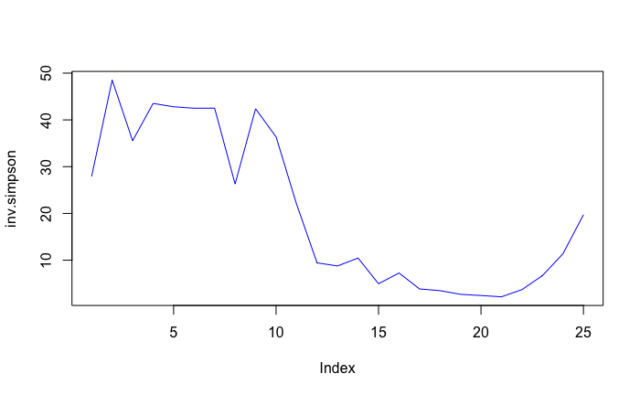

```r
inv.simpson <- diversity(otu.tab.trans, "invsimpson")
plot(inv.simpson, type = "l", col = "blue")
```

# Beta diversity

We rarefy all samples to the same sequencing depth, to reduce biases.

```r
min(rowSums(otu.tab.trans)) # We calculate the sample with the minimum amount of reads
```

```
[1] 13551
```

```r
otu.tab.trans.ss <- rrarefy(otu.tab.trans, min(rowSums(otu.tab.trans))) # Samples are rarefied to lowest number of reads
rowSums(otu.tab.trans.ss)
```

```
Isa_120223 Isa_120301 Isa_120308 Isa_120320 Isa_120321 Isa_120322 Isa_120323 Isa_120329 Isa_120403 Isa_120411 Isa_120416 Isa_120419 Isa_120423 Isa_120426 Isa_120430
     13551      13551      13551      13551      13551      13551      13551      13551      13551      13551      13551      13551      13551      13551      13551
Isa_120503 Isa_120507 Isa_120508 Isa_120509 Isa_120510 Isa_120516 Isa_120524 Isa_120621 Isa_120706 Isa_120806
     13551      13551      13551      13551      13551      13551      13551      13551      13551      13551
```

What is the number of reads these samples have been rarified to? What does it imply, do you understand how it is done?

Check that the number of OTUs are the same in the new table

```r
dim(otu.tab.trans)
```

```
[1]   25 2534
```

```r
dim(otu.tab.trans.ss)
```

```
[1]   25 2534
```

The tables have the same size, but, after removing reads, OTUs might be left with zero read abundance. These are typically those with very low abundace to begin with, and (hopefully) do not play an important in the system we are studing.

```r
length(which(colSums(otu.tab.trans) == 0))
```

```
[1] 0
```

```r
length(which(colSums(otu.tab.trans.ss) == 0))
```

```
[1] 198
```

```r
head(which(colSums(otu.tab.trans.ss) == 0)) # Show the OTUs and the position in the table that have 0 abundance for the first OTUs
```

```
OTU1026 OTU1032 OTU1043 OTU1136 OTU1250 OTU1269
     31      37      45     126     223     237
```

- *How many OTUs are empty after rarefaction?*

We can compare the number of reads for a selected OTU (in this case the 13th OTU in the list) between the origianl and the subsampled OTU table:

```r
colnames(otu.tab.trans)[13]
```

```
[1] "OTU1009"
```

```r
otu.tab.trans[, 13] # This gives the abundance of the OTU1009  across the different samples in the table that is NOT subsampled
```

```
Isa_120223 Isa_120301 Isa_120308 Isa_120320 Isa_120321 Isa_120322 Isa_120323 Isa_120329 Isa_120403 Isa_120411 Isa_120416 Isa_120419 Isa_120423 Isa_120426 Isa_120430
         0          0          0          0          0          0          0          0          0          0          0          0          0          0          0
Isa_120503 Isa_120507 Isa_120508 Isa_120509 Isa_120510 Isa_120516 Isa_120524 Isa_120621 Isa_120706 Isa_120806
         0          0          0          0          0          0          0          0          0          3
```

```r
otu.tab.trans.ss[, 13] # # This gives the abundance of the OTU1009  across the different samples in the table that IS subsampled
```

```
Isa_120223 Isa_120301 Isa_120308 Isa_120320 Isa_120321 Isa_120322 Isa_120323 Isa_120329 Isa_120403 Isa_120411 Isa_120416 Isa_120419 Isa_120423 Isa_120426 Isa_120430
         0          0          0          0          0          0          0          0          0          0          0          0          0          0          0
Isa_120503 Isa_120507 Isa_120508 Isa_120509 Isa_120510 Isa_120516 Isa_120524 Isa_120621 Isa_120706 Isa_120806
         0          0          0          0          0          0          0          0          0          3
```

We can remove the OTUs with zero abundance with a similar command as we used at the beginning of the lab:

```r
otu.tab.trans.ss.nozero <- otu.tab.trans.ss[, -(which(colSums(otu.tab.trans.ss) == 0))] # Removes OTUs with zero abundance
length(which(colSums(otu.tab.trans.ss.nozero) == 0)) # Check that no zero abundance OTUs are left
```

```
[1] 0
```

Let’s check dimensions of the tables:

```r
dim(otu.tab.trans.ss)
```

```
[1]   25 2534
```

```r
dim(otu.tab.trans.ss.nozero)
```

```
[1]   25 2336
```

*Phew* That was Part I. Now before you have a break save the data so it can be loaded if you want to use some of the same data for the next session. This way you don’t have to redo all analysis for the next lab.

```r
save.image("AB332_lab_I.RData")
```